# Probabilidad y Estadística con Python

## ¿Qué es la Estadística?

La estadística suele ser definida como la ciencia de aprender de los datos o como la ciencia de obtener conclusiones en la presencia de incertidumbre. Se relaciona principalmente con la recolección, análisis e interpretación de datos, así como también con la efectiva comunicación y presentación de los resultados basados en esos datos. Como por datos entendemos a cualquier clase de información grabada, la estadística juego un rol importante en muchas disciplinas científicas.

La estadística suele ser dividida en dos grandes ramas:

La estadística descriptiva: La cual se dedica a recolectar, ordenar, analizar y representar a un conjunto de datos, con el fin de describir apropiadamente las características de este. Calcula los parámetros estadísticos que describen el conjunto estudiado. Algunas de las herramientas que utiliza son gráficos, medidas de frecuencias, medidas de centralización, medidas de posición, medidas de dispersión, entre otras.

La estadistica inferencial: La cual estudia cómo sacar conclusiones generales para toda la población a partir del estudio de una muestra, y el grado de fiabilidad o significación de los resultados obtenidos. Sus principales herramientas son el muestreo, la estimación de parámetros y el contraste de hipótesis.

## Conceptos básicos de la estadística descriptiva

En *[estadística descriptiva](https://es.wikipedia.org/wiki/Estad%C3%ADstica_descriptiva)* se utilizan distintas medidas para intentar describir las propiedades de nuestros datos, algunos de los conceptos básicos, son:

- **Media aritmética**: La [media aritmética](https://es.wikipedia.org/wiki/Media_aritm%C3%A9tica) es el valor obtenido al sumar todos los *[datos](https://es.wikipedia.org/wiki/Dato)* y dividir el resultado entre el número total elementos. Se suele representar con la letra griega $\mu$. Si tenemos una [muestra](https://es.wikipedia.org/wiki/Muestra_estad%C3%ADstica) de $n$ valores, $x_i$, la *media aritmética*, $\mu$, es la suma de los valores divididos por el numero de elementos; en otras palabras: $$\mu = \frac{1}{n} \sum_{i}x_i$$
- **Desviación respecto a la media**: La desviación respecto a la media es la diferencia en valor absoluto entre cada valor de la variable estadística y la media aritmética. $$D_i = |x_i - \mu|$$
- **Varianza**: La [varianza](https://es.wikipedia.org/wiki/Varianza) es la media aritmética del cuadrado de las desviaciones respecto a la media de una distribución estadística. La varianza intenta describir la dispersión de los *[datos](https://es.wikipedia.org/wiki/Dato)*. Se representa como $\sigma^2$. $$\sigma^2 = \frac{\sum\limits_{i=1}^n(x_i - \mu)^2}{n} $$
- **Desviación típica**: La [desviación típica](https://es.wikipedia.org/wiki/Desviaci%C3%B3n_t%C3%ADpica) es la raíz cuadrada de la varianza. Se representa con la letra griega $\sigma$. $$\sigma = \sqrt{\frac{\sum\limits_{i=1}^n(x_i - \mu)^2}{n}} $$
- **Moda**: La moda es el valor que tiene mayor frecuencia absoluta. Se representa con $M_0$
- **Mediana**: La mediana es el valor que ocupa el lugar central de todos los datos cuando éstos están ordenados de menor a mayor. Se representa con $\widetilde{x}$.

### Ejemplos en Python

Calcular los principales indicadores de la *[estadística descriptiva](https://es.wikipedia.org/wiki/Estad%C3%ADstica_descriptiva)* con [Python](http://python.org/) es muy fácil!.

```python
# Ejemplos de estadistica descriptiva con python

import numpy as np # importando numpy
from scipy import stats # importando scipy.stats
import pandas as pd # importando pandas

np.random.seed(2131982) # para poder replicar el random
```

```python
datos = np.random.randn(5, 4) # datos normalmente distribuidos
datos
```

```
array([[ 0.46038022, -1.08942528, -0.62681496, -0.63329028],
       [-0.1074033 , -0.88138082, -0.34466623, -0.28320214],
       [ 0.94051171,  0.86693793,  1.20947882, -0.16894118],
       [-0.12790177, -0.58099931, -0.46188426, -0.18148302],
       [-0.76959435, -1.37414587,  1.37696874, -0.18040537]])
```

```python
# media arítmetica
datos.mean() # Calcula la media aritmetica de
```

```
-0.14786303590303568
```

```python
np.mean(datos) # Mismo resultado desde la funcion de numpy
```

```
-0.14786303590303568
```

```python
datos.mean(axis=1) # media aritmetica de cada fila
```

```
array([-0.47228757, -0.40416312,  0.71199682, -0.33806709, -0.23679421])
```

```python
datos.mean(axis=0) # media aritmetica de cada columna
```

```
array([ 0.0791985 , -0.61180267,  0.23061642, -0.2894644 ])
```

```python
# mediana
np.median(datos)
```

```
-0.23234258265023794
```

```python
np.median(datos, 0) # media aritmetica de cada columna
```

```
array([-0.1074033 , -0.88138082, -0.34466623, -0.18148302])
```

```python
 # Desviación típica
np.std(datos)
```

```
0.73755354584071608
```

```python
np.std(datos, 0) # Desviación típica de cada columna
```

```
array([ 0.58057213,  0.78352862,  0.87384108,  0.17682485])
```

```python
# varianza
np.var(datos)
```

```
0.54398523298221324
```

```python
np.var(datos, 0) # varianza de cada columna
```

```
array([ 0.337064  ,  0.6139171 ,  0.76359823,  0.03126703])
```

```python
# moda
stats.mode(datos) # Calcula la moda de cada columna
# el 2do array devuelve la frecuencia.
```

```
(array([[-0.76959435, -1.37414587, -0.62681496, -0.63329028]]),
 array([[ 1.,  1.,  1.,  1.]]))
```

```python
datos2 = np.array([1, 2, 3, 6, 6, 1, 2, 4, 2, 2, 6, 6, 8, 10, 6])
stats.mode(datos2) # aqui la moda es el 6 porque aparece 5 veces en el vector.
```

```
ModeResult(mode=array([6]), count=array([5]))
```

## Practica :

Generar un modelo que me permita simular el uso de recursos de los hospitales por cada una de las provincias, para ello obtener la informacion revisada en la practica de investigacion y tomar como ejemplo la practica de simulacion de atencion de paciente del COVID revisada en clase. Lo que se busca es poder generar graficos de uso de recursos:

- Costos (Generar un aproximacion de cuanto se invierte para atender a un paciente con COVID) 200
- Personal (Aproximacion del uso del personal por paciente, o el hospital)
- Camas 567
- Equipos/Insumos medicos (Obtener una aproximacion del uso de equipos medicos)
- Pacientes (Informacion obtenida desde el ministerio de salud - validar con el porcentual del tipo de paciente [ninio 10%, adulto 30%, riesgo 60%]) - Hospitalizacion 80%, Otros 20%

Para ello deberan generar un modelo lo mas cercano a la realidad, y con ayuda de la estadistica descriptiva ajustar los valores. Es importante tener como datos de entrada el dia y el numero de pacientes.

Finalmente validar el modelo con lo la realidad del pais (Investigar en base al tema el uso de los recursos publicos )

```python
import simpy
import random
import matplotlib.pyplot as plt

%matplotlib inline

# maximo de pacientes por dia
MAX_PACIENTES = 200
#total recursos
TEST = 50
# Tiempo que tarda en atenderse un paciente (minutos)
TIEMPO_ATENCION = 17
# Intervalo de tiempo en que llegan pacientes(minutos)
INTERVALO_LLEGADA = 3
# Tiempo de simulación
TIEMPO_SIMULACION = 200
#Numero de camas
NUM_CAMAS=567;
RESPIRADORES = 100

PRECIO_TEST = [100, 200]
tiempo={}
Pllegan={}
Patendidos={}
Pno={}
camas={}
costos_totales = []
cam_usadas = []
cont = []
respiradores = []
ncamas = 567
nrespiradores = 100
class Hospital(object):

    def __init__(self, environment, num_test, tiempo_atencion, camas, num_respiradores):
        # Guardamos como variable el entorno de ejecucion
        self.env=environment
        # Creamos el recurso que representa los consultorios
        self.test = simpy.Resource(environment, num_test)
        self.camas = simpy.Resource(environment, camas)
        # Variable para el tiempo de atencion
        self.tiempo_atencion = tiempo_atencion
        self.respirador = simpy.Resource(enviroment, num_respiradores)
    def atencion(self, paciente):
        yield self.env.timeout(random.randint(TIEMPO_ATENCION-2, TIEMPO_ATENCION+2))
        print(chr(27)+"[0;30m"+paciente,' Atendido')
        precio = 0
        pr = random.randint(1, 10)
        if pr > 5:
            precio = PRECIO_TEST[0]
        else:
            precio = PRECIO_TEST[1]
        print('El costo de la Prueba es de:', precio)
        costos_totales.append(precio)
        cont.append(1)

    def zona_aislamiento(self, paciente):
        t=random.randint(5, 20)
        rnd = random.randint(1,100)
        #8% de probabilidad de fallecer
        #92% de probabilidad de cura
        if rnd <= 92:
            yield self.env.timeout(t)
            print(chr(27)+"[0;33m"+'El ',paciente, 'Termina la Hospitalizacion en', t ,' Dias')
        else:
            yield self.env.timeout(t)
            print(chr(27)+"[1;30m"+'El ', paciente, 'Fallece a', t ,' Dias de Hospitalizacion')

        tiempo[paciente]=t


def llegada_paciente(env, nombre, hospital):

    # Usamos el reloj de la simulacion (env.now()) para indicar a la
    # hora que llega el paciente con el nombre pasado como parametro
    print(chr(27)+"[0;30m"+'Llega: %s a la hora %.2f.' % (nombre, (env.now+420)/60))
    Pllegan[nombre]=((env.now+420)/60)

    # Especificamos que vamos a usar un recurso (Resource) que representa
    # el consultorio del Hospital
    with hospital.test.request() as test:
        # Ocupamos los recursos
        yield test
        # Indicamos que el paciente entra al consultorio
        print(chr(27)+"[0;30m"+'Entra paciente a atenderce: %s a la hora %.2f.' % (nombre, (env.now+420)/60))

        # se realiza el test de covid_19

        rnd = random.randint(1,100)
        if rnd <= 60: # sanos 60% infectados 40%
            yield env.process(hospital.atencion(nombre))
            print(chr(27)+"[0;32m"+'Paciente Sano [%s] Atendido a las %.2f.' % (nombre, (env.now+420)/60),"Casa")
            tiempo[nombre]=((env.now+420)/60)

        else:

            yield env.process(hospital.atencion(nombre))
            print(chr(27)+"[0;31m"+'Paciente Infectado [%s] Atendido a las %.2f.' % (nombre, (env.now+420)/60),"Internado")
            with hospital.camas.request() as cama:
                # Ocupamos el consultorio

                yield cama
                # Indicamos que paciente entra al consultorio
                print(chr(27)+"[0;34m"+'se le asigna a una cama: %s a la hora %.2f.' % (nombre, (env.now+420)/60))
                global ncamas
                ncamas-= 1
                print(chr(27)+"[0;34m"+'CAMAS DISPONIBLES', ncamas)
                cam_usadas.append(ncamas)
                global nrespiradores
                nrespiradores -= 1
                respiradores.append(nrespiradores)
                respirador = random.randint(1, 10)
                if respirador%2 == 0:
                    with hospital.respirador.request() as resp:
                        yield resp
                        print(chr(27)+"[0;34m"+'se le asigna a un respirador: %s a la hora %.2f.' % (nombre, (env.now+420)/60))
                        print(chr(27)+"[0;34m"+'RESPIRADORES DISPONIBLES', nrespiradores)







def ejecutar_simulacion(env, num_test, tiempo_atencion, intervalo, camas, num_respiradores):
    hospital=Hospital(env, num_test, tiempo_atencion, camas, num_respiradores)
    # Creamos 5 llegadas de pacientes iniciales
    for i in range(5):
        edad = random.randint(5, 65)
        env.process(llegada_paciente(env, 'Paciente-%d'%(i+1),hospital))

    # Ejecutamos la simulacion
    while True:
        yield env.timeout(random.randint(intervalo-3, intervalo+3))
        edad = random.randint(5, 65)
        i+=1
        # Mientras se atienden los pacientes generamos mas pacientes
        env.process(llegada_paciente(env, 'Paciente-%d'%(i+1),hospital))

print('Hospital')

# Creamos el entorno de simulacion
env=simpy.Environment()
env.process(ejecutar_simulacion(env, TEST, TIEMPO_ATENCION, INTERVALO_LLEGADA, NUM_CAMAS, RESPIRADORES))

# Ejecutamos el proceso durante el tiempo de simulacion
env.run(until = TIEMPO_SIMULACION)
print("\n")

media = sum(costos_totales)/len(costos_totales)
print(chr(27)+"[0;34m"+'MEDIA ',media)


print(chr(27)+"[0;34m"+"Numero de pacientes :",len(Pllegan))
print(chr(27)+"[0;34m"+"Numero de pacientes Atendidos:",len(tiempo))
print(chr(27)+"[0;34m"+"Numero de pacientes se quedaron sin atender y fallecieron:",len(Pllegan)-len(tiempo))
```

[output not shown]

[output cut: 289 more lines]

```
Paciente Infectado [Paciente-54] Atendido a las 10.28. Internado
se le asigna a una cama: Paciente-54 a la hora 10.28.
CAMAS DISPONIBLES 546
Paciente-55  Atendido
El costo de la Prueba es de: 200
Paciente Sano [Paciente-55] Atendido a las 10.30. Casa
Paciente-57  Atendido
El costo de la Prueba es de: 200
Paciente Sano [Paciente-57] Atendido a las 10.32. Casa


MEDIA  156.140350877193
Numero de pacientes : 62
Numero de pacientes Atendidos: 36
Numero de pacientes se quedaron sin atender y fallecieron: 26
```

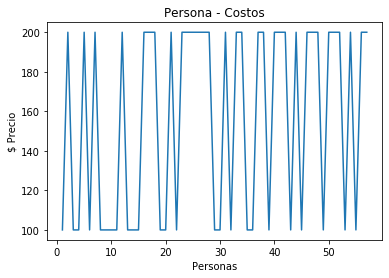

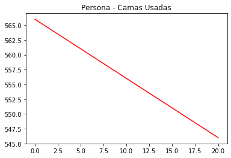

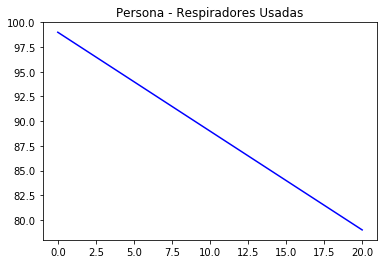

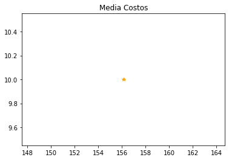

```python
for i in range(len(cont)):
    cont[i] = i + 1
pp.plot(cont, costos_totales)
pp.title('Persona - Costos')
pp.ylabel('$ Precio')
pp.xlabel('Personas')
pp.show()

pp.plot([i for i in range(len(cam_usadas))], cam_usadas,  color = 'red')
pp.title('Persona - Camas Usadas')
pp.show()

pp.plot([i for i in range(len(respiradores))], respiradores,  color = 'blue')
pp.title('Persona - Respiradores Usadas')
pp.show()

pp.plot(media, 10, '*',  color = 'orange')
pp.title('Media Costos')
pp.show()
```

## Conclusiones

Se obtinen los siguites resultados para la provincia de Cotopaxi en donde hasta la fecha se cuenta 207 infectados, en donde se cuenta con los siguientes centros de salud:

- Ministerio de Salud Pública
- Ministerio de Defensa Nacional
- Instituto Ecuatoriano de Seguridad Social
- Fiscomisionales
- Privados con fines de lucro

y en total en camas suma 567 y el total de insumos en este caso respiradores 100 no se encontraron mas resultados, y por la situacion del pais los datos no son los correctos por lo tanto la simulacion no se apega mucho a la realidad.

## Recomendaciones

Se recomienda tener un banco de datos exactos y estos datos deben ser de todo el entorno de esta forma la simulacion dara resultados mas precios y apegados a la realidad.

## Opiniones

Al no saber los datos reales del pais es muy dificil obtener resultado coerentes ya que la estadistica descriptiva y todo modelo de simulacion necesita datos excatos y limpios y de esta forma obtener resultados coerentes, por la falta de informacion y en este caso de la provincia de Cotopaxi la siluacion no se apega al escenario actual de contagios en la provincia